# Final Project

Liv Lindberg

### Load Packages and Read in Data

```r
# load packages
library(rvest)
library(tidyverse)
library(genius)
library(tidytext)
library(gridExtra)
data("stop_words")
data("sentiments")
```

#### 1980s

```r
# read webpage for Grammy Awards
webpage <- read_html("https://en.wikipedia.org/wiki/Grammy_Award_for_Record_of_the_Year")

# copy xpath for table of 1980s
XPATH80 <- '/html/body/div[3]/div[3]/div[5]/div[1]/table[5]'

# run the following to create table of songs from 1980s
table_1980 <-
  webpage %>%
  html_nodes(xpath = XPATH80) %>%
  html_table(fill = TRUE)

d1980 <- table_1980[[1]]

head(d1980)
```

|  | Year[I] | Record | Artist(s) | Production team |
| --- | --- | --- | --- | --- |
| 1 | 1980[44] | NA | NA | NA |
| 2 | 1980[44] | "What a Fool Believes" | The Doobie Brothers | Ted Templeman, producer |
| 3 | 1980[44] | "After the Love Has Gone" | Earth, Wind & Fire | Maurice White, producer |
| 4 | 1980[44] | "I Will Survive" | Gloria Gaynor | Freddie Perren & Dino Fekaris, producers |
| 5 | 1980[44] | "The Gambler" | Kenny Rogers | Larry Butler, producer |
| 6 | 1980[44] | "You Don't Bring Me Flowers" | Barbra Streisand & Neil Diamond | Bob Gaudio, producer |

#### 1990s

```r
# read webpage for Grammy Awards
webpage <- read_html("https://en.wikipedia.org/wiki/Grammy_Award_for_Record_of_the_Year")

# copy xpath for table of 1990s
XPATH90 <- '/html/body/div[3]/div[3]/div[5]/div[1]/table[6]'

# run the following to create table of songs from 1990s
table_1990 <-
  webpage %>%
  html_nodes(xpath = XPATH90) %>%
  html_table(fill = TRUE)

d1990 <- table_1990[[1]]

head(d1990)
```

|  | Year[I] | Record | Artist(s) | Production team |
| --- | --- | --- | --- | --- |
| 1 | 1990[54] | NA | NA | NA |
| 2 | 1990[54] | "Wind Beneath My Wings" | Bette Midler | Arif Mardin, producer |
| 3 | 1990[54] | "The End of the Innocence" | Don Henley | Don Henley & Bruce Hornsby, producers |
| 4 | 1990[54] | "She Drives Me Crazy" | Fine Young Cannibals | David Z & Fine Young Cannibals, producers |
| 5 | 1990[54] | "We Didn't Start the Fire" | Billy Joel | Mick Jones & Billy Joel, producers |
| 6 | 1990[54] | "The Living Years" | Mike + The Mechanics | Christopher Neil & Mike Rutherford, producers |

#### 2000s

```r
# read webpage for Grammy Awards
webpage <- read_html("https://en.wikipedia.org/wiki/Grammy_Award_for_Record_of_the_Year")

# copy xpath for table of 2000s
XPATH00 <- '/html/body/div[3]/div[3]/div[5]/div[1]/table[7]'

# run the following to create table of songs from 2000s
table_2000 <-
  webpage %>%
  html_nodes(xpath = XPATH00) %>%
  html_table(fill = TRUE)

d2000 <- table_2000[[1]]

head(d2000)
```

|  | Year[I] | Record | Artist(s) | Production team |
| --- | --- | --- | --- | --- |
| 1 | 2000[64] | NA | NA | NA |
| 2 | 2000[64] | "Smooth" | Santana featuring Rob Thomas | Matt Serletic, producer; David Thoener, engineer/mixer |
| 3 | 2000[64] | "Believe" | Cher | Brian Rawling & Mark Taylor, producers; Mark Taylor, engineer/mixer |
| 4 | 2000[64] | "I Want It That Way" | Backstreet Boys | Kristian Lundin & Max Martin, producers; Kristian Lundin & Max Martin, engineers/mixers |
| 5 | 2000[64] | "Livin' la Vida Loca" | Ricky Martin | Desmond Child & Robi Rosa, producers; Charles Dye, engineer/mixer |
| 6 | 2000[64] | "No Scrubs" | TLC | Kevin "Shekspere" Briggs, producer; Leslie Brathwaite & Carlton Lynn, engineers/mixers |

#### 2010s

```r
# read webpage for Grammy Awards
webpage <- read_html("https://en.wikipedia.org/wiki/Grammy_Award_for_Record_of_the_Year")

# copy xpath for table of 2010s
XPATH10 <- '/html/body/div[3]/div[3]/div[5]/div[1]/table[8]'

# run the following to create table of songs from 2010s
table_2010 <-
  webpage %>%
  html_nodes(xpath = XPATH10) %>%
  html_table(fill = TRUE)

d2010 <- table_2010[[1]]

head(d2010)
```

|  | Year[I] | Record | Artist(s) | Production team |
| --- | --- | --- | --- | --- |
| 1 | 2010[74] | NA | NA | NA |
| 2 | 2010[74] | "Use Somebody" | Kings of Leon | Jacquire King & Angelo Petraglia, producers; Jacquire King, engineer/mixer |
| 3 | 2010[74] | "Halo" | Beyoncé | Beyoncé Knowles & Ryan Tedder, producers; Jim Caruana, Mark "Spike" Stent & Ryan Tedder, engineers/mixers |
| 4 | 2010[74] | "I Gotta Feeling" | The Black Eyed Peas | David Guetta & Frederick Riesterer, producers; will.i.am, Dylan "3-D" Dresdow & Padraic "Padlock" Kerin, engineers/mixers |
| 5 | 2010[74] | "Poker Face" | Lady Gaga | RedOne, producer; Robert Orton, RedOne & Dave Russell, engineers/mixers |
| 6 | 2010[74] | "You Belong with Me" | Taylor Swift | Nathan Chapman & Taylor Swift, producers; Chad Carlson & Justin Niebank, engineers/mixers |

### Data Wrangling

```r
# remove the NAs
d1980 <- na.omit(d1980)
d1990 <- na.omit(d1990)
d2000 <- na.omit(d2000)
d2010 <- na.omit(d2010)
```

```r
# removed bracketed values from each year
d1980 <- d1980 %>%
  mutate(`Year[I]` = trimws(str_replace(`Year[I]`, "\\[.*?\\]", "")))
d1990 <- d1990 %>%
  mutate(`Year[I]` = trimws(str_replace(`Year[I]`, "\\[.*?\\]", "")))
d2000 <- d2000 %>%
  mutate(`Year[I]` = trimws(str_replace(`Year[I]`, "\\[.*?\\]", "")))
d2010 <- d2010 %>%
  mutate(`Year[I]` = trimws(str_replace(`Year[I]`, "\\[.*?\\]", "")))
```

```r
# clean variables
d1980 <- d1980 %>%
  rename(year = `Year[I]`,
         track = Record,
         artist = `Artist(s)`) %>%
  subset(select = -c(`Production team`))

d1990 <- d1990 %>%
  rename(year = `Year[I]`,
         track = Record,
         artist = `Artist(s)`) %>%
  subset(select = -c(`Production team`))

d2000 <- d2000 %>%
  rename(year = `Year[I]`,
         track = Record,
         artist = `Artist(s)`) %>%
  subset(select = -c(`Production team`))

d2010 <- d2010 %>%
  rename(year = `Year[I]`,
         track = Record,
         artist = `Artist(s)`) %>%
  subset(select = -c(`Production team`))
```

```r
# make a table with lyrics for each song in 1980s
lyrics80s <- d1980 %>%
  add_genius(artist, track, type = "lyrics")
```

```r
# make a table with lyrics for each song in 1990s
lyrics90s <- d1990 %>%
  add_genius(artist, track, type = "lyrics")
```

```r
# make a table with lyrics for each song in 2000s
lyrics00s <- d2000 %>%
  add_genius(artist, track, type = "lyrics")
```

```r
# make a table with lyrics for each song in 2010s
lyrics10s <- d2010 %>%
  add_genius(artist, track, type = "lyrics")
```

```r
# join all lyrics data frames
allLyrics <- rbind(lyrics80s, lyrics90s, lyrics00s, lyrics10s)
```

```r
# add decades variable
allLyrics <- allLyrics %>%
mutate(decade = ifelse(year %in% 1980:1989, "1980s",
                                     ifelse(year %in% 1990:1999, "1990s",
                                            ifelse(year %in% 2000:2009, "2000s",
                                                   ifelse(year %in% 2010:2019, "2010s", "NA")))))
```

### Data Visualization

#### Graph 1

```r
# create data frame to extract words in each song into new variable "word"
wordsPerSong1 <-
  allLyrics %>%
  unnest_tokens(word, lyric) %>%
  select(decade, track_title, word)

# find count of words per track
wordsPerSong2 <-
  aggregate(word ~ track_title, data = wordsPerSong, NROW)

# create new data frame joining two frames
wordsPerSong <-
  left_join(wordsPerSong1, wordsPerSong2, by="track_title") %>%
  subset(select = -c(`word.x`)) %>%
  rename(avgWord = word.y) %>%
  group_by(track_title) %>%
  distinct(track_title, .keep_all = TRUE) %>%
  na.omit()
```

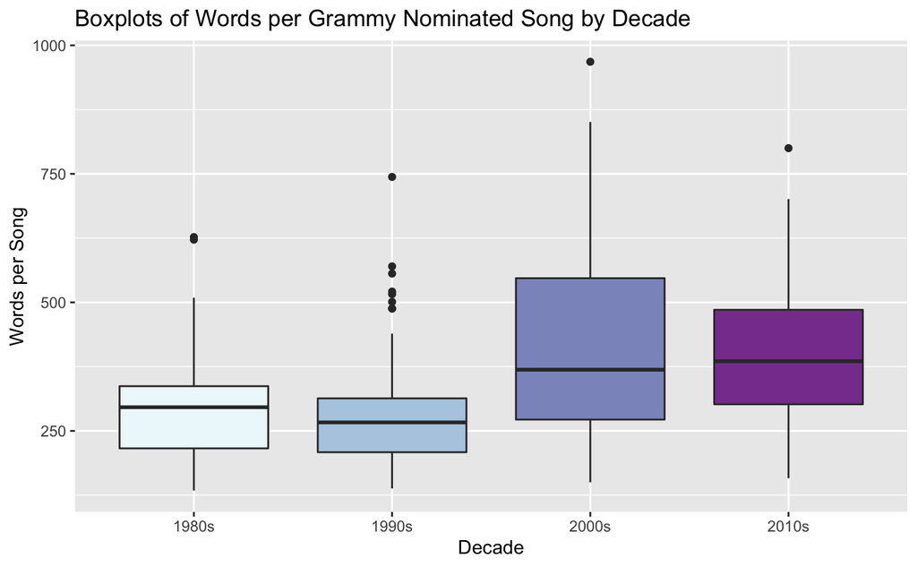

```r
# create graph 1 using wordsPerSong data frame
ggplot(wordsPerSong) +
 aes(x = decade, y = avg_word, fill = decade) +
 geom_boxplot() +
 labs(x = "Decade", y = "Words per Song", title = "Boxplots of Words per Grammy Nominated Song by Decade") +
  theme(legend.position="none") +
  scale_fill_brewer(palette="BuPu")
```

```r
 theme_linedraw()
```

[output not shown]

[output cut: 372 more lines]

[output not shown]

Graph 1 is showing the distribution of song word count for each decade. This graph also includes stop words, so the word count includes simple terms like “the”, “a”, and others. The boxplots show that the 2000s had the largest spread of word count in songs, and the high outlier of almost 1000 words appears to be the highest word count for a single song.

#### Graph 2

```r
# remove stop words
word = data.frame()
word[1,1]=c('ba')
word[2,1]=c('du')
word[3,1]=c('yeah')
word[4,1]=c('da')
word[5,1]=c('ya')
word[6,1]=c('ooh')
word[7,1]=c('gonna')
word[8,1]=c('na')
word[9,1]=c('uh')
word[10,1]=c('la')
word[11,1]=c('hol')
colnames(word) <- c('word')

verse_words <- allLyrics %>%
  unnest_tokens(word, lyric)

ft <- verse_words %>%
  anti_join(stop_words) %>%
  anti_join(word)
```

In order to remove the 11 addition stop words from the data, I created a single column data frame called “word” which included all of the specified values. I used the function unnest_tokens to extract the words from each line of the lyrics data frame. Then finally, using anti_join, I removed the stop_words from the tidytext package as well as the 11 stop words from the data frame “word”.

```r
# create data frame of top 10 words
topten <- ft %>%
  count(word, sort = TRUE) %>%
  top_n(10)
```

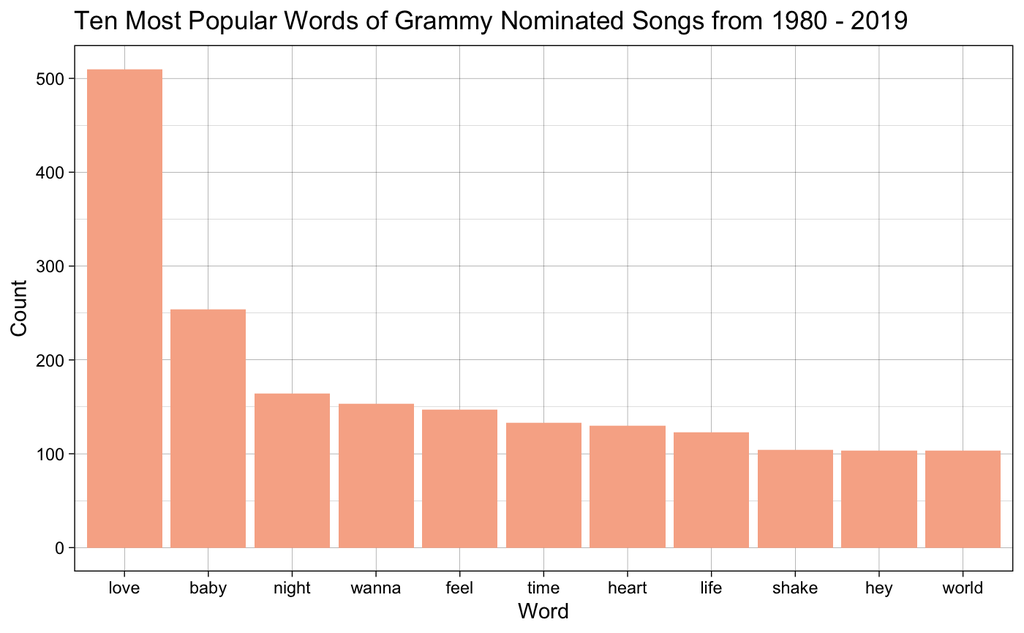

```r
# create graph of top 10 words
ggplot(topten) +
 aes(x = reorder(word, -n), fill = word, weight = n) +
 geom_bar(fill = "#f8b195") +
 labs(x = "Word", y = "Count", title = "Ten Most Popular Words of Grammy Nominated Songs from 1980 - 2019") +
 theme_linedraw() +
 theme(legend.position = "none")
```

#### Graph 3

```r
# create data frame for top ten for 1980s
graph80s <- ft %>%
  filter(decade == "1980s") %>%
  select(decade, track_title, word) %>%
  count(word, sort = TRUE) %>%
  top_n(10)

# create data frame for top ten for 1990s
graph90s <- ft %>%
  filter(decade == "1990s") %>%
  select(decade, track_title, word) %>%
  count(word, sort = TRUE) %>%
  top_n(10)

# create data frame for top ten for 2000s
graph00s <- ft %>%
  filter(decade == "2000s") %>%
  select(decade, track_title, word) %>%
  count(word, sort = TRUE) %>%
  top_n(10)

# create data frame for top ten for 2010s
graph10s <- ft %>%
  filter(decade == "2010s") %>%
  select(decade, track_title, word) %>%
  count(word, sort = TRUE) %>%
  top_n(10)
```

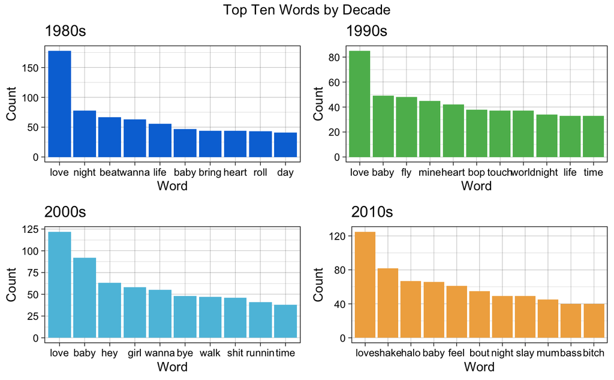

```r
# graph the frames
p1 <- ggplot(graph80s)+
  aes(x = reorder(word, -n), weight = n) +
 geom_bar(fill = "#0275d8") +
 labs(x = "Word", y = "Count", title = "1980s") +
 theme_linedraw()
p2 <- ggplot(graph90s)+
  aes(x = reorder(word, -n), weight = n) +
 geom_bar(fill = "#5cb85c") +
 labs(x = "Word", y = "Count", title = "1990s") +
 theme_linedraw()
p3 <- ggplot(graph00s) +
  aes(x = reorder(word, -n), weight = n) +
 geom_bar(fill = "#5bc0de") +
 labs(x = "Word", y = "Count", title = "2000s") +
 theme_linedraw()
p4 <- ggplot(graph10s) +
  aes(x = reorder(word, -n), weight = n) +
 geom_bar(fill = "#f0ad4e") +
 labs(x = "Word", y = "Count", title = "2010s") +
 theme_linedraw()

grid.arrange(p1, p2, p3, p4, nrow = 2, ncol = 2, top = "Top Ten Words by Decade")
```

Graph 3 shows the top 10 words in each decade. All 4 graphs show a similar distribution, with “love” being significantly more popular than any other word, and then it is followed by other popular words in each specific decade. This figure also reveals that Grammy nominated songs from 2000s and 2010s use swear words more frequently than in previous decades.

#### Graph 4

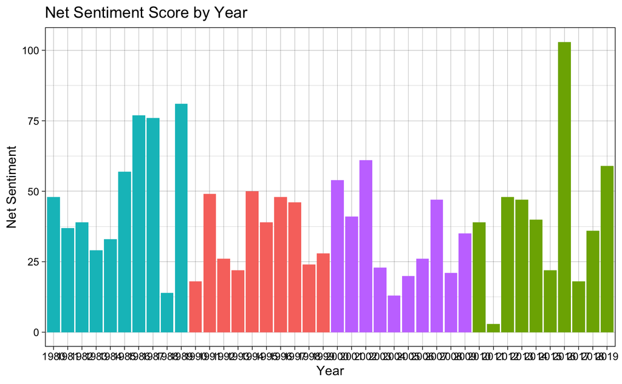

```r
# join sentiments frame with lyrics and change sentiment values to 0 and 1
graph4 <- ft %>%
  inner_join(sentiments) %>%
  mutate(sentiment = ifelse(sentiment == "positive",1,0)) %>%
  select(year, sentiment)
# find sum of sentiment values for each year
library(data.table)
graph4 <- data.table(graph4)
graph4 <- graph4[,list(sentiment=sum(sentiment)), by='year']

# assign colors for each decade
graph4 <- graph4 %>%
  mutate(color = ifelse(year %in% 1980:1989, "red",
                                     ifelse(year %in% 1990:1999, "orange",
                                            ifelse(year %in% 2000:2009, "yellow",
                                                   ifelse(year %in% 2010:2019, "purple", "NA")))))

# graph the data
ggplot(graph4) +
 aes(x = year, weight = sentiment, fill = color) +
 geom_bar() +
 labs(x = "Year", y = "Net Sentiment", title = "Net Sentiment Score by Year") +
 theme_linedraw() +
  theme(legend.position = "none")
```

Graph 4 shows the net sentiment score by across each year, and is also color coordinated by decade so each decade can be easily compared. Since 2016 is the highest bar with a score of over 100, this means that Grammy nominated songs from this year had the most positive words in their lyrics.

#### Graph 5

```r
graph5 <- ft %>%
  inner_join(sentiments) %>%
  mutate(sentiment = ifelse(sentiment == "positive",1,0)) %>%
  select(decade, sentiment)
graph5 <- data.table(graph5)
graph5[,list(sentiment=mean(sentiment)), by='decade']
```

| decade | sentiment |
| --- | --- |
| 1980s | 0.5783274 |
| 1990s | 0.5192878 |
| 2000s | 0.3678533 |
| 2010s | 0.4104847 |

[figure not shown]

```r
ggplot(graph5) +
 aes(x = decade, weight = sentiment, fill = decade) +
 geom_bar() +
 labs(x = "Decade", y = "Mean Sentiment Score", title = "Mean Sentiment Score by Decade") +
  scale_fill_brewer(palette="RdBu") +
 theme_linedraw() +
  theme(legend.position = "none")
```

#### Graph 6

```r
model <- lm_fit <- lm(year ~ sentiment, data=graph6)
summary(lm_fit)
```

[output not shown]

```
Call:
lm(formula = year ~ sentiment, data = graph6)

Residuals:
     Min       1Q   Median       3Q      Max
-19.0727  -8.8927   0.0569   9.3161  20.5093

Coefficients:
              Estimate Std. Error t value Pr(>|t|)
(Intercept) 2001.61257    4.10560 487.532   <2e-16 ***
sentiment     -0.05291    0.09162  -0.578    0.567
---
Signif. codes:  0 ‘***’ 0.001 ‘**’ 0.01 ‘*’ 0.05 ‘.’ 0.1 ‘ ’ 1

Residual standard error: 11.79 on 38 degrees of freedom
Multiple R-squared:  0.008701,  Adjusted R-squared:  -0.01739
F-statistic: 0.3336 on 1 and 38 DF,  p-value: 0.567
```

[figure not shown]

```r
ggplot(graph6) +
  aes(x=as.numeric(year), y=sentiment, color=decade) +
  geom_point()+
  geom_smooth(color='red',data = lm_fit,se = FALSE)+
  labs(x = "Year", y = "Net Sentiment", title = "Net Sentiment Score by Year of Grammy Nominated Records from 1980 - 2019 with Linear Model Fit") +
  scale_x_continuous(breaks=seq(1980, 2020, 10)) +
 theme_linedraw()
```